# KSPM: A Package For Kernel Semi-Parametric Models

### An example of the variable selection procedure

Suppose we fit a single kernel semi-parametric model with a gaussian kernel to adjust the social media features in the CSM data. The kernel part contains the set of social media features. We want to select the relevant variables to be included in the kernel. We therefore can perform a stepwise variable selection procedure based on AIC, while letting $\rho$ vary at each iteration. To do so, we first fit the full model including all features.

```r
> csm.fit4 <- kspm(response = "Ratings", kernel = ~Kernel(~ Sentiment + Views
+    + Likes + Dislikes + Comments + Aggregate.Followers, kernel.function =
+    "gaussian"), data = csm)
```

Then, we apply the `stepKSPM()` command on the full model as follows.

```r
> stepKSPM(csm.fit4, kernel.lower = ~1, kernel.upper = ~ Sentiment + Views
+    + Likes + Dislikes + Comments + Aggregate.Followers, direction = "both",
+    k = 2, kernel.param = "change", data = csm)
```

At each iteration, R returns the current model, and the list of variables that may be added or removed.

```r
Start: AIC = 913.2
Linear part: ~ 1
Kernel part: ~ Sentiment + Views + Likes + Dislikes + Comments +
               Aggregate.Followers

                        Part      AIC
- Sentiment           kernel 910.8282
<none>                       913.1769
- Views               kernel 913.9753
- Likes               kernel 917.6532
- Comments            kernel 921.2163
- Aggregate.Followers kernel 925.4491
- Dislikes            kernel 969.4304


Step: AIC = 910.8
Linear part: ~ 1
Kernel part: ~ Views + Likes + Dislikes + Comments + Aggregate.Followers

                        Part      AIC
- Views               kernel 905.2908
<none>                       910.8282
+ Sentiment           kernel 913.1769
- Aggregate.Followers kernel 915.5481
- Likes               kernel 916.8125
- Comments            kernel 921.9627
- Dislikes            kernel 970.3804


Step: AIC = 905.3
Linear part: ~ 1
Kernel part: ~ Likes + Dislikes + Comments + Aggregate.Followers

                        Part      AIC
<none>                       905.2908
+ Views               kernel 910.8282
+ Sentiment           kernel 913.9753
- Aggregate.Followers kernel 916.0224
- Comments            kernel 917.8758
- Likes               kernel 925.0230
- Dislikes            kernel 968.2502
```

The final model includes the variables `Likes`, `Dislikes`, `Comments` and `Aggregate.Followers`.

# Example 2: Consumption of energy data

Our second example illustrates how *KSPM* may be efficient with complex data as time series and show how the choice of tuning parameters impacts the results.

The `energy` data is a set of data on energy consumption each hour on Ouessant island (France) from September the 13th, 2015 to October the 4th, 2015, that were made publicly available by *Electricité de France* at https://iles-ponant-edf-sei.opendatasoft.com. The data set also contains corresponding meteorologic data such as temperature (Celsius degrees), pressure (Pa) and humidity rate (g/m$^3$). These measures are collected by *Meteo France* every 3 hours and are publicly available on www.infoclimat.fr. We obtained hourly values by linear interpolation. In total the data set contains 504 measurements.

```r
> data("energy")
> head(energy)
```

```r
     power       date        T        P       HR hour hour.num
1 526.1667 2015-09-13 12.43333 1007.933 81.66667  01h        1
2 495.0000 2015-09-13 12.36667 1007.167 82.33333  02h        2
3 446.1667 2015-09-13 12.30000 1006.400 83.00000  03h        3
4 365.8333 2015-09-13 12.30000 1005.833 82.66667  04h        4
5 341.0000 2015-09-13 12.30000 1005.267 82.33333  05h        5
6 352.3333 2015-09-13 12.30000 1004.700 82.00000  06h        6
```

These data demonstrate strong periodicity depending on time of day (Figure 4). Of note, if data had been collected for a period longer than one year, a second periodicity would be visible corresponding to seasons.

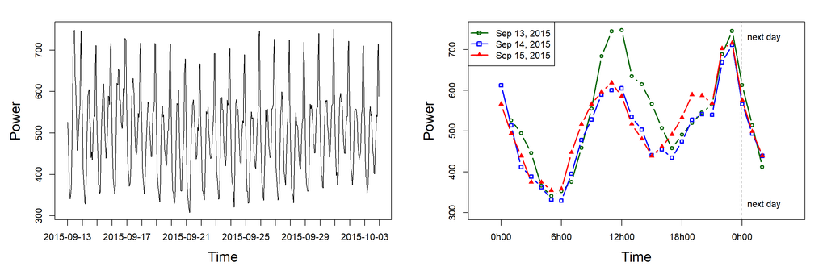

Figure 4: Pattern of energy consumption over the entire data set from Ouessant island (Left) and on the three first days (Right). The power is observed each hour and show a one day periodicity.

We will consider the 408 first measurements (17 days) as the training set. The others 4 days will be used as a test set, where we want to predict the energy consumption.

```r
> energy_train_ <- energy[1:408, ]
> energy_test_ <- energy[409:504, ]
```

### Modeling

We fit a single kernel semi-parametric model to the training data. We assume that energy depends linearly on temperature (`T`), and therefore this variable is included in the linear part of the model. The other meteorologic data, as well as hours in 24-hour numeric format, are included in the kernel part of the model. We used a gaussian kernel and we left the $\rho$ parameter free to be estimated by the model.

```r
> energy.fit1 <- kspm(response = "power", linear = ~T, kernel = ~Kernel(~
+    hour.num + P + HR, kernel.function = "gaussian") , data = energy_train_)
> energy.fit1$kernel.info$Ker1$rho
```

```r
     par1
0.7028723
```

### Impact of the $\rho$ parameter on derivatives and predictions

We recomputed the model using other values for the $\rho$ parameter to explore sensitivity of the results to this key kernel parameter. Values were chosen tenfold larger and smaller than the estimated value of $0.70$ in `energy.fit1`.

```r
> energy.fit2 <- kspm(response = "power", linear = ~T, kernel = ~Kernel(~
+    hour.num + P + HR, kernel.function = "gaussian", rho = 7) , data =
+    energy_train_)
> energy.fit3 <- kspm(response = "power", linear = ~T, kernel = ~Kernel(~
+    hour.num +  P + HR, kernel.function = "gaussian", rho = 0.07) , data =
+    energy_train_)
```

Figure 5 displays the predictions obtained on both the training and test data sets, as well as the derivatives, as a function of the hours variable, for the three models `energy.fit1`, `energy.fit2` and `energy.fit3` that differ only on the value of the tuning parameter $\rho$.

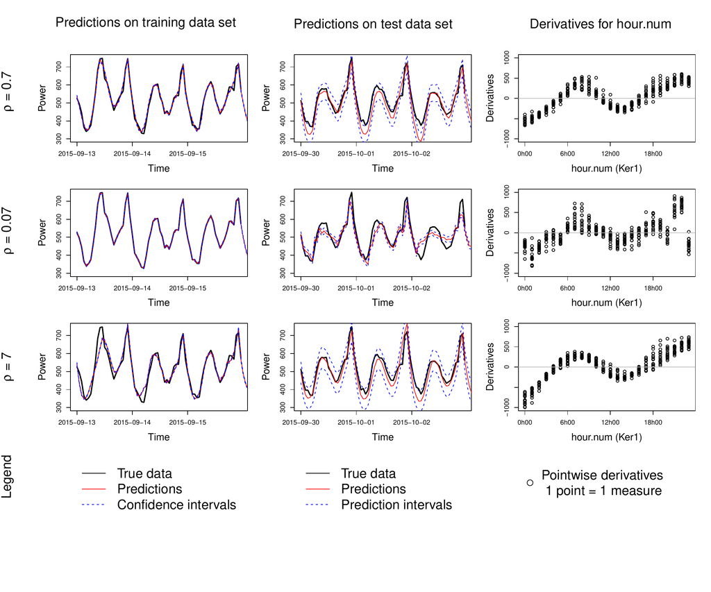

Figure 5: Predictions and derivatives obtained for different values of $\rho$ in the energy dataset. Predictions on training data set are displayed with confidence intervals, whereas predictions on test data set are displayed with prediction intervals. The first row corresponds to the model `energy.fit1` with estimated $\rho=0.7$. The second row corresponds to a tenfold smaller $\rho=0.07$ (overfitting) and third row corresponds to a tenfold larger $\rho=7$ (underfitting). The last column shows how the choice of $\rho$ impacts the derivatives.

The first row of Figure 5 corresponds to the model with the value of $\rho$ estimated by the model. Predictions fit well for both the training and the test sets. The derivative graph shows that between 6h00 and 12h00 and between 18h00 and 23h00 the derivatives are positive. This result is coherent with the increase of energy consumption during these times of the day (Figure 4-Right). Inversely between 0h00 and 6h00 and between 12h00 and 18h00, the energy consumption decreases as showed by negative values of derivatives. One might have expected that derivative values should be close between 0h00 and 23h00 but the peak consumption observed at 23h00 everyday (Figure 4) is probably associated with a sudden change in derivative values that is difficult to smooth accurately.

# Example 3: Gene-gene interaction

This example shows how the interaction test may be applied to gene-gene interaction using standard linear kernel and SNPs involved in genes.

We simulated a data of 300 subjects and 9 SNPs, 6 belonging to gene A and 3 belonging to gene B, using the `glSim()` function into the [*adegenet*](https://CRAN.R-project.org/package=adegenet) R package (Jombart and Ahmed 2011). SNPs are coded 0, 1 or 2 according to the number of alleles of each type carried by the subject. A continuous outcome was simulated as a linear combination of the interaction terms between the 6 SNPs of gene A and the three SNPs of gene B, where the weight coefficients where randomly and uniformly chosen in the interval $\left[-2;0\right]$. We added an intercept of 100 and a normally distributed error of mean 0 and standard deviation 15. Code details are available in Supplement S1.

Let `y` be the vector of continuous outcomes, `geneA` be the $300 \times 6$ matrix of SNPs belonging to gene A and `geneB` be the $300 \times 3$ matrix of SNPs belonging to gene B.

We test the interaction between the genes using the code below. Of note, in this example, the data are specified using vector and design matrices instead of using formulae and data frame as in previous examples.

```r
> gene.fit <- kspm(response = y, kernel = ~ Kernel(geneA, kernel = "linear")
+    * Kernel(geneB, kernel = "linear"))
> summary(gene.fit, kernel.test = "Ker1:Ker2")
```

```r
Call:
kspm(response = y, kernel = ~Kernel(geneA, kernel = "linear") *
    Kernel(geneB, kernel = "linear"))

Sample size:
n = 300

Residuals:
     Min       Q1   Median       Q3      Max
-34.1111  -8.7300  -1.1659   9.7299  38.6887

Coefficients (linear part):
            Estimate Std. Error  t value      Pr(>|t|)
(Intercept) 88.80183  0.8178659 108.5775 2.531469e-231

Score test for non-parametric kernel:
            lambda       tau     p-value
Ker1:Ker2 199.4587 0.9862838 0.006646781

Residual standard error: 14.03 on 280.74 effective degrees of freedom
Multiple R-squared: 0.2387, Adjusted R-squared: 0.1892
```

The result suggests that genes A and B impact the continuous outcome y through their interaction.

# Summary

This new *KSPM* package provides a flexible implementation of the kernel semi-parametric model and its extensions in a unified framework, using nomenclatures similar to other regression R packages. Thanks to the kernel trick, such a model is useful when interest lies in prediction and our `predict()` command makes this easy. Nevertheless, inference is also possible through the confidence intervals and tests provided by the package, such as through the `summary()` command. Moreover, we have provided many options for model diagnostics (residuals, leverage, ...), model interpretation (derivatives, ...) and model comparisons (AIC, stepwise, ...).  
Model estimation for multiple kernel model is based on an iterative estimation of regression parameters we develop and prove in Supplement S2. Penalization and tuning parameter estimation involves `optimize()` and `DEoptim()` functions. The both integrate C code ensuring a faster convergence of the algorithms. However, the overall *KSPM* algorithm includes inversion of $n \times n$ matrices, thereby resulting in slower optimization as $n$ increases. It would improve *KSPM*’s performance to combine matrix inversion code and optimization code in a single efficient set of C code and we are considering this for a future implementation. It is worth noting, however, that computation time is not severely impacted by the number of predictors even if $n << q$.

In the *KRLS* package, (Hainmueller and Hazlett 2013) proposed a marginal test for the individual effect of each variable included in the kernel. We decided not to implement this test in our package since the marginal effect may mask interesting but symmetric effects of a variable on the continuous outcome. However, we have implemented a test of hypothesis based on variance components to test the joint effect of a set of variables on the continuous outcome. The distribution of this test statistic follows a mixture of $\chi^2$ distributions that we approximated using Davies’ method (Davies 1980), available through the [*CompQuadForm*](https://CRAN.R-project.org/package=CompQuadForm) package (de Micheaux 2017; Duchesne and de Micheaux 2010). The distribution can also be approximated by a scaled chi-squared distribution using Satterthwaite’s method where parameters are computed by moment matching. (Schifano et al. 2012) compared the two approximation methods on the type-I error rate in a single kernel semi-parametric model and showed that the rate is inflated with Satterthwaite’s method when the $\alpha$-level is low, and therefore we recommend the Davies method. To assess global testing of multiple kernels, we implemented a sum of the L single-kernel test statistics as an overall test statistic. In general, the computation of the $p$ value of this overall test involves the joint distribution of ($Q_1$, ... $Q_L$). To derive analytical values for the overall $p$ value, one can use techniques similar to those used in (Sun et al. 2019), which relied on a copula-based model to approximate this joint distribution. This last option is not yet implemented in *KSPM*.

For all our tests, the model has to be re-estimated under the null hypothesis for the kernel of interest. If the resulting null model still contains one or more kernel part(s), we made the choice to recompute penalization parameter(s), since this choice ensures an optimized model under the null hypothesis. However, we have also decided to leave the kernel tuning parameters fixed when re-estimating under the null. Indeed, a change in tuning parameters induces a change in the choice of kernel functions - and thus in model assumptions - and hence, keeping the tuning parameters fixed ensures comparability of model assumptions under the null and the alternative hypotheses.

In our *KSPM* package, we have also included an algorithm for selection of variables based on these information criteria. Backward, forward or stepwise approaches can be chosen for single kernel semi-parametric models. Although these concepts may be easily extended to the case of multiple kernel models, such analyses require large computing times. Parallelization of such a process may greatly increase the appeal of this procedure. For now, we recommend investigating variables within a single kernel before starting to fit multiple kernel models.

In summary, the *KSPM* package is a flexible comprehensible option for studying the effects of groups of variables on a continuous outcome. These tools may be extended to the case of binary or survival outcomes in future work.

# Acknowledgements

CS was supported by the Institute for Data Valorization (IVADO) fellowship. CG was supported by the Ludmer Centre for Neuroinformatics and Mental Health, the Canadian Institutes for Health Research, as well as the CIHR PJT 148620 grant. SJ is a recipient of a Canada Research Chair in neurodevelopmental disorders, and a chair from the Jeanne et Jean Louis Levesque Foundation. This research was enabled in part by support provided by Calcul Quebec (http://www.calculquebec.ca) and Compute Canada (www.computecanada.ca). This work is supported by a grant from the Brain Canada Multi-Investigator initiative and CIHR grant 159734 (SJ, CMTG). This work was also supported by an NIH award U01 MH119690 granted (SJ) and U01 MH119739.

**SUPPLEMENT**

# Supplement S1

We simulated a $300 \times 9$ matrix representing the number of minor allele (0, 1 or 2) of 300 subjects for 9 SNPs, 6 belonging to gene A and 3 belonging to gene B, using the `glSim()` function into the *adegenet* R package.

```r
> library(adegenet)
> set.seed(78)
> SNPdata <- as.matrix(glSim(n.ind = 300, n.snp.nonstruc = 9, n.snp.struc = 0, k = 1,
  LD = FALSE, ploidy = 2))
```

We may deduce two matrices, one with data belonging to gene A and one with data belonging to gene B.

```r
> geneA <- SNPdata[,1:6]
> geneB <- SNPdata[,7:9]
```

Then we computed the matrix of interactions between SNPs from gene A and SNPs from geneB.

```r
> SNPdataAB <- matrix(NA, nrow = 300, ncol = 6*3)
> k <- 1
> for (i in 1:6) {
    for (j in 1:3) {
      SNPdataAB[,k] <- SNPdataA[,i] * SNPdataB[,j]
      k <- k+1
    }
  }
```

A continuous outcome was simulated as a linear combination of the interaction terms between the 6 SNPs of gene A and the three SNPs of gene B, where the weight coefficients where randomly and uniformly chosen in the interval $\left[-2;0\right]$ using the following code.

```r
> beta <- as.matrix(runif(6*3,-2,0), nrow = 300)
> y <- 100 + SNPdataAB %*% beta + rnorm(n, 0, 15)
```

Of note, we added an intercept of 100 and a normally distributed error of mean 0 and standard deviation 15.

# Supplement S2

Estimating the kernel semi-parametric model parameters consists in estimating $\alpha_1, ..., \alpha_L$ and $\beta$. Then, estimators of $h_1(.)$, ..., $h_L(.)$ are deduced from $\hat{\alpha}_1, ..., \hat{\alpha}_L$. When there are multiple kernels, estimation is iterative and so we proceed as follows. Partial derivatives of $l(\beta, h)$ according to $\alpha_1, ..., \alpha_L$ and $\beta$ lead to the following equations:

$$\label{eq:betaM}
\hat{\beta} = \left\lbrace X^\top \left( I - \sum\limits_{\ell = 1}^L
K_{\ell} G_{\ell}^{-1} M_{\ell} \right) X \right\rbrace^{-1} X^\top
\left(I - \sum\limits_{\ell = 1}^L K_{\ell} G_{\ell}^{-1}
M_{\ell}\right) Y (\#eq:betaM)$$

$$\label{eq:alphaM}
\forall \ell \in \left\lbrace 1,..., L\right\rbrace, \quad
\hat{\alpha}_{\ell} = G_{\ell}^{-1} M_{\ell}
\left(Y-X\hat{\beta}\right) (\#eq:alphaM)$$
where $I$ is the $n \times n$ identity matrix and $\forall \ell \in \left\lbrace 1, ..., L \right\rbrace$, $G_{\ell}$ and $M_{\ell}$ are computed using an iterative process as described below:

- Re-order elements $\alpha_{1...L}$, $K_{1...L}$ and $\lambda_{1...L}$ such that the last is the $\ell^{th}$ element
- Note $\alpha_{(1)}$, ..., $\alpha_{(L)}$, $K_{(1)}$, ..., $K_{(L)}$ and $\lambda_{(1)}$, ..., $\lambda_{(L)}$ the re-ordered elements with $\alpha_{(L)} = \alpha_{\ell}$, $K_{(L)} = K_{\ell}$ and $\lambda_{(L)} = \lambda_{\ell}$
- Define iteratively $\mathcal{M}_{(0)...(L)}$ and $\mathcal{G}_{(1)...(L)}$ by $\mathcal{M}_{(0)} = I$ the $n \times n$ identity matrix and $\forall m \in \left\lbrace 1, ..., L \right\rbrace$:  
  $\mathcal{G}_{(m)} = \lambda_{(m)} I + \mathcal{M}_{(m-1)} K_{(m)}$  
  $\mathcal{M}_{(m)} = \left(I - \mathcal{M}_{(m-1)} K_{(m)} \mathcal{G}_{(m)}^{-1} \right) \mathcal{M}_{(m-1)}$
- Compute $G_{\ell}$ and $M_{\ell}$ as:  
  $G_{\ell} = \mathcal{G}_{(L)}$  
  $M_{\ell} = \mathcal{M}_{(L-1)}$

Whereas the parameter estimation for single kernel model has been largely demonstrated, the equations for computing multiple kernel parameters were not theoretically developed yet. Above, we propose an iterative way to estimate the parameters for all kernel models. Below, we propose the proof for equations (@ref(eq:betaM)) and (@ref(eq:alphaM)).  
**Proof:**  
Partial derivatives of penalized likelihood (@ref(eq:pll)) lead to equations below:

$$\label{eq:derivll}
\left\lbrace \begin{aligned}
X^\top (Y - X\beta - \sum\limits_{\ell = 1}^L K_{\ell} \alpha_{\ell})
& = 0 \\
Y - X\beta - \sum\limits_{m = 1}^L K_{m} \alpha_{m} - \lambda_{\ell}
\alpha_{\ell} & = 0 \quad \forall \ell \in \left\lbrace 1,...,L
\right\rbrace
\end{aligned} \right. (\#eq:derivll)$$

*Proposition 1:* $\forall k \in \left\lbrace 1, ..., L-1\right\rbrace, \alpha_{(k)} = \mathcal{G}_{(k)}^{-1} \mathcal{M}_{(k - 1)} \left( Y - X\beta - \sum\limits_{m = k + 1}^L K_{(m)} \alpha_{(m)} \right)$
*Proposition 2:* if proposition 1 is true until $k$, then
$$\sum\limits_{j = 1}^k K_{(m)}\alpha_{(m)} = (I -
\mathcal{M}_{(k)})\left( Y - X\beta - \sum\limits_{m = k + 1}^L
K_{(m)}\alpha_{(m)} \right)$$

*(Proofs of propositions 1 and 2 are given below.)*  
Now, suppose proposition 1 and proposition 2 are true.

$$\begin{aligned}
(\ref{eq:derivll}) \Rightarrow && Y - X\beta - \sum\limits_{m =
1}^L K_{(m)}\alpha_{(m)} - \lambda_{(L)}\alpha_{(L)} &= 0 \\
\Leftrightarrow && Y - X\beta - \sum\limits_{m = 1}^{L-1}
K_{(m)}\alpha_{(m)} - K_{(L)}\alpha_{(L)} - \lambda_{(L)}\alpha_{(L)}
&= 0 \\
\Leftrightarrow && Y - X\beta - (I - \mathcal{M}_{(L-1)})\left(
Y - X\beta - K_{(L)}\alpha_{(L)} \right) - K_{(L)}\alpha_{(L)} -
\lambda_{(L)}\alpha_{(L)}& = 0 \\
\Leftrightarrow && \left( \lambda_{(L)}I + \mathcal{M}_{(L-1)}
K_{(L)} \right) \alpha_{(L)} - \mathcal{M}_{(L-1)} (Y - X\beta) &=
0 \\
\end{aligned}$$

Then, $\alpha_{\ell} = \alpha_{(L)} = \mathcal{G}_{(L)}^{-1} \mathcal{M}_{(L - 1)} \left( Y - X\beta \right)$. Let $G_{\ell}$ and $M_{\ell}$ the $n \times n$ matrix defined as $G_{\ell} = \mathcal{G}_{(L)}$ and $M_{\ell} = \mathcal{M}_{(L - 1)}$, thus $\alpha_{\ell} = G_{\ell}^{-1} M_{\ell} \left( Y - X\beta \right)$. All this process is done for each $\ell \in \left\lbrace 1, ..., L\right\rbrace$.  
Now, we can derive the estimate for $\beta$.

$$\begin{aligned}
(\ref{eq:derivll}) \Rightarrow && X^\top \left( Y - X\beta -
\sum\limits_{\ell = 1}^L K_{\ell}\alpha_{\ell} \right) & = 0 \\
\Leftrightarrow && X^\top\left( Y - X\beta - \sum\limits_{\ell =
1}^L K_{\ell}G_{\ell}^ {-1}M_{\ell} (Y - X\beta)\right) & = 0 \\
\Leftrightarrow && X^\top\left( I - \sum\limits_{\ell = 1}^L
K_{\ell}G_{\ell}^ {-1}M_{\ell} \right) Y & = X^\top\left( I -
\sum\limits_{\ell = 1}^L K_{\ell}G_{\ell}^ {-1}M_{\ell} \right) X\beta
\\
\end{aligned}$$
Thus $\beta = \left\lbrace X^\top\left( I - \sum\limits_{\ell = 1}^L K_{\ell}G_{\ell}^ {-1}M_{\ell} \right) X \right\rbrace^{-1} X^\top\left( I - \sum\limits_{\ell = 1}^L K_{\ell}G_{\ell}^ {-1}M_{\ell} \right) Y$.
*Proof of proposition 1:*
$\bullet$ Proposition 1 is true for $k = 1$:

$$\begin{aligned}
\text{(\ref{eq:derivll})} \Rightarrow && Y - X\beta
- \sum\limits_{m = 1}^L K_{(m)} \alpha_{(m)} - \lambda_{(1)}
\alpha_{(1)} & = 0 \\
\Leftrightarrow && Y - X\beta - \sum\limits_{m = 2}^L K_{(m)}
\alpha_{(m)} - K_{(1)} \alpha_{(1)} - \lambda_{(1)} \alpha_{(1)} &
= 0 \\
\Leftrightarrow && \mathcal{M}_{(0)} \left( Y - X\beta -
\sum\limits_{m = 2}^L K_{(m)} \alpha_{(m)} \right) & = \left(
\lambda_{(1)} I + \mathcal{M}_{(0)} K_{(1)} \right) \alpha_{(1)} \\
\Leftrightarrow && \mathcal{G}_{(1)}^{-1} \mathcal{M}_{(0)}
\left( Y - X\beta - \sum\limits_{m = 2}^L K_{(m)} \alpha_{(m)} \right)
& = \alpha_{(1)} \\
\end{aligned}$$

$\bullet$ If proposition 1 is true for $k$, then proposition 1 is true for $k + 1$:  
According to proposition 2:

$$\begin{aligned}
\sum\limits_{m = 1}^k K_{(m)} \alpha_{(m)} &= (I -
\mathcal{M}_{(k)}) \left(Y - X\beta - \sum\limits_{m = k + 1}^L
K_{(m)}\alpha_{(m)} \right) \\
& = (I - \mathcal{M}_{(k)}) \left(Y - X\beta - \sum\limits_{m = k +
2}^L K_{(m)}\alpha_{(m)} \right) - (I - \mathcal{M}_{(k)}) K_{(k+1)}
\alpha_{(k+1)}
\end{aligned}$$

$$\begin{aligned}
\text{(\ref{eq:derivll})} \Rightarrow && Y - X\beta -
\sum\limits_{m = 1}^L K_{(m)} \alpha_{(m)} - \lambda_{(k+1)}
\alpha_{(k+1)} & = 0 \\
\Leftrightarrow && Y - X\beta - \sum\limits_{m = 1}^k K_{(m)}
\alpha_{(m)} - K_{(k+1)} \alpha_{(k+1)} - \sum\limits_{m = k + 2}^L
K_{(m)} \alpha_{(m)} - \lambda_{(k+1)} \alpha_{(k+1)} &= 0 \\
\Leftrightarrow && - \left( (I - \mathcal{M}_{(k)}) \left(Y -
X\beta - \sum\limits_{m = k + 2}^L K_{(m)}\alpha_{(m)} \right) - (I -
\mathcal{M}_{(k)}) K_{(k+1)} \alpha_{(k+1)} \right) & \\
&& + Y - X\beta - K_{(k+1)} \alpha_{(k+1)} - \sum\limits_{m = k
+ 2}^L K_{(m)} \alpha_{(m)} - \lambda_{(k+1)} \alpha_{(k+1)} &
= 0 \\
\Leftrightarrow && \mathcal{M}_{(k)} \left( Y - X\beta -
\sum\limits_{m = k + 2}^L K_{(m)} \alpha_{(m)} \right) -
\mathcal{M}_{(k)} K_{(k+1)} \alpha_{(k+1)} - \lambda_{(k+1)}
\alpha_{(k+1)} & = 0 \\
\Leftrightarrow && \mathcal{M}_{(k)} \left(Y - X\beta -
\sum\limits_{m = k + 2}^L K_{(m)} \alpha_{(m)} \right)
- \mathcal{G}_{(k+1)} \alpha_{(k+1)} & = 0 \\
\Leftrightarrow && \mathcal{G}_{(k+1)}^{-1} \mathcal{M}_{(k)}
\left(Y - X\beta - \sum\limits_{m = k + 2}^L K_{(m)} \alpha_{(m)}
\right) & = \alpha_{(k+1)} \\
\end{aligned}$$

*Proof of proposition 2:*  
$\bullet$ Proposition 2 is true for $k = 1$:  
Suppose $\alpha_{(1)} = \mathcal{G}_{(1)}^{-1}\mathcal{M}_{(0)} \left( Y - X\beta - \sum\limits_{m = 2}^L K_{(m)}\alpha_{(m)} \right)$.

$$\begin{aligned}
\sum\limits_{m = 1}^1 K_{(m)} \alpha_{(m)} & = K_{(1)}\alpha_{(1)}
\\
& = K_{(1)} \mathcal{G}_{(1)}^{-1}\mathcal{M}_{(0)} \left( Y -
X\beta - \sum\limits_{m = 2}^L K_{(m)}\alpha_{(m)} \right) \\
& = \left( I - \mathcal{M}_{(0)} + \mathcal{M}_{(0)} K_{(1)}
G_1^{-1} \mathcal{M}_{(0)} \right) \left( Y - X\beta - \sum\limits_{m =
2}^L K_{(m)}\alpha_{(m)} \right) \\
& = \left( I - (I - \mathcal{M}_{(0)} K_{(1)} G_1^{-1})
\mathcal{M}_{(0)}\right) \left( Y - X\beta - \sum\limits_{m = 2}^L
K_{(m)}\alpha_{(m)} \right) \\
& = \left(I - \mathcal{M}_{(1)} \right) \left(Y - X\beta -
\sum\limits_{m = 2}^L K_{(m)} \alpha_{(m)}\right) \\
\end{aligned}$$

$\bullet$ If proposition 2 is true for $k$, then proposition 2 is true for $k + 1$:  
Suppose proposition 1 is true until $k+1$, then $\forall j \in \left\lbrace 1, ..., k+1 \right\rbrace$,

$\alpha_{(j)} = \mathcal{G}_{(j)}^{-1}\mathcal{M}_{(j-1)} \left( Y - X\beta - \sum\limits_{m = j+1}^L K_{(m)}\alpha_{(m)} \right)$

$$\begin{aligned}
\sum\limits_{m = 1}^{k+1} K_{(m)} \alpha_{(m)} & = \sum\limits_{m =
1}^{k} K_{(m)} \alpha_{(m)} + K_{(k+1)} \alpha_{(k+1)}\\
& = (I - \mathcal{M}_{(k)}) \left(Y - X\beta - \sum\limits_{m = k
+ 1}^L K_{(m)}\alpha_{(m)} \right) + K_{(k+1)} \alpha_{(k+1)} \\
& = (I - \mathcal{M}_{(k)}) \left(Y - X\beta - \sum\limits_{m = k
+ 2}^L K_{(m)}\alpha_{(m)} \right) + \mathcal{M}_{(k)}
K_{(k+1)}\alpha_{(k+1)} \\
& = (I - \mathcal{M}_{(k)}) \left(Y - X\beta - \sum\limits_{m = k
+ 2}^L K_{(m)}\alpha_{(m)} \right) + \mathcal{M}_{(k)} K_{(k+1)}
\mathcal{G}_{(k+1)}^{-1} \mathcal{M}_{(k)} \left(Y - X\beta -
\sum\limits_{m = k + 2}^L K_{(m)}\alpha_{(m)} \right) \\
& = (I - \mathcal{M}_{(k)} + \mathcal{M}_k K_{(k+1)}
\mathcal{G}_{(k+1)}^{-1} \mathcal{M}_k) \left(Y - X\beta -
\sum\limits_{m = k + 2}^L K_{(m)}\alpha_{(m)} \right) \\
& = (I - (I+ \mathcal{M}_{(k)} K_{(k+1)}
\mathcal{G}_{(k+1)}^{-1}) \mathcal{M}_{(k)}) \left(Y - X\beta -
\sum\limits_{m = k + 2}^L K_{(m)}\alpha_{(m)} \right) \\
& = (I - \mathcal{M}_{(k+1)}) \left(Y - X\beta - \sum\limits_{m =
k + 2}^L K_{(m)}\alpha_{(m)} \right) \\
\end{aligned}$$

$\square$

Of note, for $L = 1$, equations (@ref(eq:betaM)) and (@ref(eq:alphaM)) correspond to those provided in (Liu, Lin, and Ghosh 2007).

Ahmed, Mehreen, Maham Jahangir, Hammad Afzal, Awais Majeed, and Imran Siddiqi. 2015. “Using Crowd-Source Based Features from Social Media and Conventional Features to Predict the Movies Popularity.” In *IEEE International Conference on Smart City/SocialCom/SustainCom (SmartCity)*, 273–78. IEEE. https://doi.org/10.1109/SmartCity.2015.83.

Ardia, David, Katharine Mullen, Brian Peterson, and Joshua Ulrich. 2020. *DEoptim: Global Optimization by Differential Evolution*. https://CRAN.R-project.org/package=DEoptim.

Bates, Douglas, Martin Maechler, Ben Bolker, and Steven Walker. 2019. *Lme4: Linear Mixed-Effects Models Using ’Eigen’ and S4*. https://CRAN.R-project.org/package=lme4.

Brent, Richard P. 2013. *Algorithms for Minimization Without Derivatives*. Prentice-Hall, Englewood Clifts, New Jersey.

Chen, Jun, Wenan Chen, Ni Zhao, Michael C Wu, and Daniel J Schaid. 2016. “Small Sample Kernel Association Tests for Human Genetic and Microbiome Association Studies.” *Genetic Epidemiology* 40 (1): 5–19. https://doi.org/10.1002/gepi.21934.

Davies, Robert B. 1980. “Distribution of a Linear Combination of Chi-Square Random Variables: Algorithm AS 155.” *Applied Statistics* 29 (3): 323–33.

de Micheaux, P. Lafaye. 2017. *CompQuadForm: Distribution Function of Quadratic Forms in Normal Variables*. https://CRAN.R-project.org/package=CompQuadForm.

Duchesne, P., and P. Lafaye de Micheaux. 2010. “Computing the Distribution of Quadratic Forms: Further Comparisons Between the Liu-Tang-Zhang Approximation and Exact Methods.” *Computational Statistics and Data Analysis* 54: 858–62. https://doi.org/10.1016/j.csda.2009.11.025.

Ge, Tian, Thomas E Nichols, Debashis Ghosh, Elizabeth C Mormino, Jordan W Smoller, Mert R Sabuncu, and the Alzheimer’s Disease Neuroimaging Initiative. 2015. “A Kernel Machine Method for Detecting Effects of Interaction Between Multidimensional Variable Sets: An Imaging Genetics Application.” *Neuroimage* 109: 505–14. https://doi.org/10.1016/j.neuroimage.2015.01.029.

Hainmueller, Jens, and Chad Hazlett. 2013. “Kernel Regularized Least Squares: Reducing Misspecification Bias with a Flexible and Interpretable Machine Learning Approach.” *Political Analysis* 22 (2): 143–68.

Hazlett, Jens Hainmueller AND Chad. 2017. *KRLS: Kernel-Based Regularized Least Squares*. https://CRAN.R-project.org/package=KRLS.

Jombart, T., and I. Ahmed. 2011. “Adegenet 1.3-1: New Tools for the Analysis of Genome-Wide SNP Data.” *Bioinformatics*. https://doi.org/10.1093/bioinformatics/btr521.

Kimeldorf, George, and Grace Wahba. 1971. “Some Results on Tchebycheffian Spline Functions.” *Journal of Mathematical Analysis and Applications* 33 (1): 82–95. https://doi.org/10.1016/0022-247X(71)90184-3.

Lee, Seunggeun, with contributions from Larisa Miropolsky, and Michael Wu. 2017. *SKAT: SNP-Set (Sequence) Kernel Association Test*. https://CRAN.R-project.org/package=SKAT.

Li, Shaoyu, and Yuehua Cui. 2012a. “Gene-Centric Gene-Gene Interaction: A Model-Based Kernel Machine Method.” *The Annals of Applied Statistics* 6 (3): 1134–61. https://doi.org/10.1214/12-AOAS545.

———. 2012b. *SPA3G: R Package for the Method of Li and Cui (2012)*. https://CRAN.R-project.org/package=SPA3G.

Liu, Dawei, Xihong Lin, and Debashis Ghosh. 2007. “Semiparametric Regression of Multidimensional Genetic Pathway Data: Least-Squares Kernel Machines and Linear Mixed Models.” *Biometrics* 63 (4): 1079–88. https://doi.org/10.1111/j.1541-0420.2007.00799.x.

Marceau, Rachel, Wenbin Lu, Shannon Holloway, Michèle M Sale, Bradford B Worrall, Stephen R Williams, Fang-Chi Hsu, and Jung-Ying Tzeng. 2015. “A Fast Multiple-Kernel Method with Applications to Detect Gene-Environment Interaction.” *Genetic Epidemiology* 39 (6): 456–68. https://doi.org/10.1002/gepi.21909.

Meyer, David, Evgenia Dimitriadou, Kurt Hornik, Andreas Weingessel, and Friedrich Leisch. 2018. *E1071: Misc Functions of the Department of Statistics, Probability Theory Group (Formerly: E1071), TU Wien*. https://CRAN.R-project.org/package=e1071.

Mullen, Katharine M, David Ardia, David L Gil, Donald Windover, and James Cline. 2009. “DEoptim: An R Package for Global Optimization by Differential Evolution.” *Journal of Statistical Software* 40 (6): 1–26. http://www.jstatsoft.org/v40/i06/.

Oualkacha, Karim, Zari Dastani, Rui Li, Pablo E Cingolani, Timothy D Spector, Christopher J Hammond, J Brent Richards, Antonio Ciampi, and Celia MT Greenwood. 2013. “Adjusted Sequence Kernel Association Test for Rare Variants Controlling for Cryptic and Family Relatedness.” *Genetic Epidemiology* 37 (4): 366–76. https://doi.org/10.1002/gepi.21725.

Pinheiro, José, Douglas Bates, and R-core. 2019. *Nlme: Linear and Nonlinear Mixed Effects Models*. https://CRAN.R-project.org/package=nlme.

Racine, Jeffrey S., and Tristen Hayfield. 2020. *Np: Nonparametric Kernel Smoothing Methods for Mixed Data Types*. https://CRAN.R-project.org/package=np.

Schifano, Elizabeth D, Michael P Epstein, Lawrence F Bielak, Min A Jhun, Sharon LR Kardia, Patricia A Peyser, and Xihong Lin. 2012. “SNP Set Association Analysis for Familial Data.” *Genetic Epidemiology* 36 (8): 797–810. https://doi.org/10.1002/gepi.21676.

Schramm, Catherine. 2020. *KSPM: Kernel Semi-Parametric Models*. https://CRAN.R-project.org/package=KSPM.

Sun, Jianping, Karim Oualkacha, Celia MT Greenwood, and Lajmi Lakhal-Chaieb. 2019. “Multivariate Association Test for Rare Variants Controlling for Cryptic and Family Relatedness.” *Canadian Journal of Statistics* 47 (1): 90–107. https://doi.org/10.1002/cjs.11475.

Therneau, Terry M. 2018. *Coxme: Mixed Effects Cox Models*. https://CRAN.R-project.org/package=coxme.

Wang, Changqing, Jianping Sun, Bryan Guillaume, Tian Ge, Derrek P Hibar, Celia MT Greenwood, Anqi Qiu, and the Alzheimer’s Disease Neuroimaging Initiative. 2017. “A Set-Based Mixed Effect Model for Gene-Environment Interaction and Its Application to Neuroimaging Phenotypes.” *Frontiers in Neuroscience* 11: 191. https://doi.org/10.3389/fnins.2017.00191.

Wood, Simon. 2020. *Mgcv: Mixed GAM Computation Vehicle with Automatic Smoothness Estimation*. https://CRAN.R-project.org/package=mgcv.

Wu, Michael C, Seunggeun Lee, Tianxi Cai, Yun Li, Michael Boehnke, and Xihong Lin. 2011. “Rare-Variant Association Testing for Sequencing Data with the Sequence Kernel Association Test.” *The American Journal of Human Genetics* 89 (1): 82–93. https://doi.org/10.1016/j.ajhg.2011.05.029.

Zhang, Daowen, and Xihong Lin. 2003. “Hypothesis Testing in Semiparametric Additive Mixed Models.” *Biostatistics* 4 (1): 57–74. https://doi.org/10.1093/biostatistics/4.1.57.